# Module 3: Data Exploration

The following tutorial contains examples of Python code for data exploration. You should refer to the "Data Exploration" chapter of the "Introduction to Data Mining" book (available at https://www-users.cs.umn.edu/~kumar001/dmbook/index.php) to understand some of the concepts introduced in this tutorial notebook. The notebook can be downloaded from http://www.cse.msu.edu/~ptan/dmbook/tutorials/tutorial3/tutorial3.ipynb.

Data exploration refers to the preliminary investigation of data in order to better understand its specific characteristics. There are two key motivations for data exploration:

1. To help users select the appropriate preprocessing and data analysis technique used.
2. To make use of humans’ abilities to recognize patterns in the data.

Read the step-by-step instructions below carefully. To execute the code, click on the cell and press the SHIFT-ENTER keys simultaneously.

**There are additional questions embedded among the code segments that you are to answer. Read carefully!**

Edit your answer into the markdown blocks.  
Finally run the whole script and download your file as an .html file.

## 3.1. Summary Statistics

Summary statistics are quantities, such as the mean and standard deviation, that capture various characteristics of a potentially large set of values with a single number or a small set of numbers. In this tutorial, we will use the Iris sample data, which contains information on 150 Iris flowers, 50 each from one of three Iris species: Setosa, Versicolour, and Virginica. Each flower is characterized by five attributes:

- sepal length in centimeters
- sepal width in centimeters
- petal length in centimeters
- petal width in centimeters
- class (Setosa, Versicolour, Virginica)

In this tutorial, you will learn how to:

- Load a CSV data file into a Pandas DataFrame object.
- Compute various summary statistics from the DataFrame.

To execute the sample program shown here, make sure you have installed the Pandas library (see Module 2).

**1.** First, you need to download the [Iris dataset](http://archive.ics.uci.edu/ml/datasets/Iris) from the UCI machine learning repository.

**Code:** The following code uses Pandas to read the CSV file and store them in a DataFrame object named data. Next, it will display the first five rows of the data frame.

```python
import pandas as pd

data = pd.read_csv('http://archive.ics.uci.edu/ml/machine-learning-databases/iris/iris.data',header=None)
data.columns = ['sepal length', 'sepal width', 'petal length', 'petal width', 'class']

data.head()
```

|  | sepal length | sepal width | petal length | petal width | class |
| --- | --- | --- | --- | --- | --- |
| 0 | 5.1 | 3.5 | 1.4 | 0.2 | Iris-setosa |
| 1 | 4.9 | 3.0 | 1.4 | 0.2 | Iris-setosa |
| 2 | 4.7 | 3.2 | 1.3 | 0.2 | Iris-setosa |
| 3 | 4.6 | 3.1 | 1.5 | 0.2 | Iris-setosa |
| 4 | 5.0 | 3.6 | 1.4 | 0.2 | Iris-setosa |

**2.** For each quantitative attribute, calculate its average, standard deviation, minimum, and maximum values.

**Code:**

```python
from pandas.api.types import is_numeric_dtype

for col in data.columns:
    if is_numeric_dtype(data[col]):
        print('%s:' % (col))
        print('\t Mean = %.2f' % data[col].mean())
        print('\t Standard deviation = %.2f' % data[col].std())
        print('\t Minimum = %.2f' % data[col].min())
        print('\t Maximum = %.2f' % data[col].max())
```

```
sepal length:
	 Mean = 5.84
	 Standard deviation = 0.83
	 Minimum = 4.30
	 Maximum = 7.90
sepal width:
	 Mean = 3.05
	 Standard deviation = 0.43
	 Minimum = 2.00
	 Maximum = 4.40
petal length:
	 Mean = 3.76
	 Standard deviation = 1.76
	 Minimum = 1.00
	 Maximum = 6.90
petal width:
	 Mean = 1.20
	 Standard deviation = 0.76
	 Minimum = 0.10
	 Maximum = 2.50
```

**QUESTION A:** The for-loop above is iterating through the data frame. Explain why the if-statement makes this code more robust.

**YOUR ANSWER:** The if statement prevents any non-numeric columns from being used with mean(), std() etc.

**3.** For the qualitative attribute (class), count the frequency for each of its distinct values.

**Code:**

```python
data['class'].value_counts()
```

```
class
Iris-setosa        50
Iris-versicolor    50
Iris-virginica     50
Name: count, dtype: int64
```

**4.** It is also possible to display the summary for all the attributes simultaneously in a table using the describe() function. If an attribute is quantitative, it will display its mean, standard deviation and various quantiles (including minimum, median, and maximum) values. If an attribute is qualitative, it will display its number of unique values and the top (most frequent) values.

**Code:**

```python
data.describe(include='all')
```

|  | sepal length | sepal width | petal length | petal width | class |
| --- | --- | --- | --- | --- | --- |
| count | 150.000000 | 150.000000 | 150.000000 | 150.000000 | 150 |
| unique | NaN | NaN | NaN | NaN | 3 |
| top | NaN | NaN | NaN | NaN | Iris-setosa |
| freq | NaN | NaN | NaN | NaN | 50 |
| mean | 5.843333 | 3.054000 | 3.758667 | 1.198667 | NaN |
| std | 0.828066 | 0.433594 | 1.764420 | 0.763161 | NaN |
| min | 4.300000 | 2.000000 | 1.000000 | 0.100000 | NaN |
| 25% | 5.100000 | 2.800000 | 1.600000 | 0.300000 | NaN |
| 50% | 5.800000 | 3.000000 | 4.350000 | 1.300000 | NaN |
| 75% | 6.400000 | 3.300000 | 5.100000 | 1.800000 | NaN |
| max | 7.900000 | 4.400000 | 6.900000 | 2.500000 | NaN |

Note that count refers to the number of non-missing values for each attribute.

**5.** For multivariate statistics, you can compute the covariance and correlation between pairs of attributes.

**Code:**

```python
print('Covariance:')
data.cov()
```

```
Covariance:
```

[output not shown]

```python
print('Correlation:')
data.corr()
```

```
Correlation:
```

[output not shown]

Below in the next section are some scatterplots of these attributes or variables.

## 3.2. Data Visualization

Data visualization is the display of information in a graphic or tabular format. Successful visualization requires that the data (information) be converted into a visual format so that the characteristics of the data and the relationships among data items or attributes can be analyzed or reported.

In this tutorial, you will learn how to display the Iris data created in Section 3.1. To execute the sample program shown here, make sure you have installed the matplotlib library package (see Module 0 on how to install Python packages).

**1.** First, we will display the histogram for the sepal length attribute by discretizing it into 8 separate bins and counting the frequency for each bin.

**Code:**

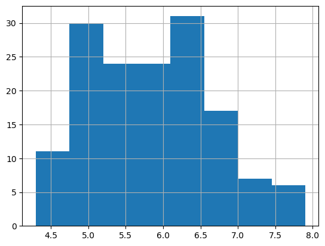

```python
%matplotlib inline

data['sepal length'].hist(bins=8)
```

**QUESTION C:** How might you address the problem that a histogram depends on the number and location of the bins? Experiment with different bin numbers.

**YOUR ANSWER:** I don't know if this is the most sound rule but I might try adding as many bins as can be displayed without creating extra gaps in the histogram. For the sepal length histogram it seems like if you have 29 bins a gap forms between bars on the right and more gaps start forming as you go into numbers above 29. I settled for 25 since it's a multiple of 5 and it's less than 29, but maybe there's a more scientific approach to determining the appropriate number of bins.

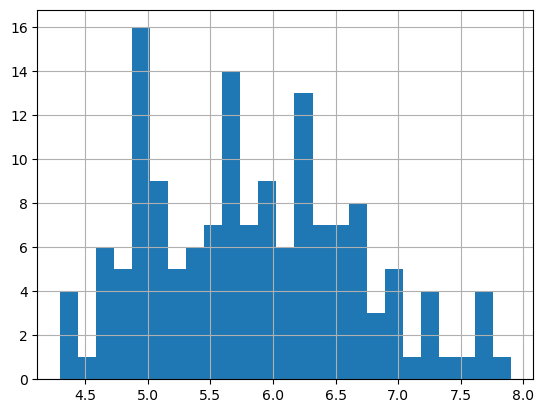

```python
data['sepal length'].hist(bins=25)
```

**2.** A boxplot can also be used to show the distribution of values for each attribute.

**Code:**

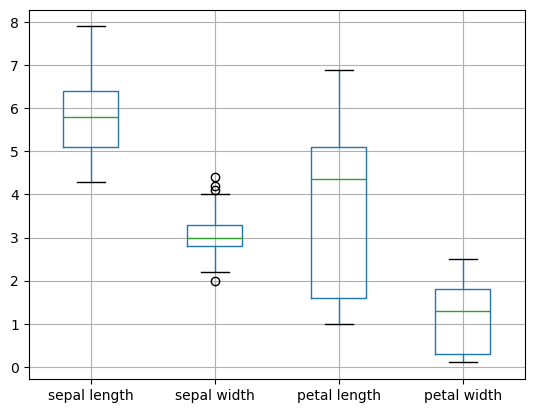

```python
data.boxplot()
```

**QUESTION D:** Describe how a box plot can give information about whether the value of an attribute is symmetrically distributed. What can you say about the symmetry of the distributions of the attributes shown in the boxplot above?

**YOUR ANSWER:** The different horizontal lines that make up a box and whisker plot represent different percentiles of the distribution and the points represent outliers, so the symmetry of the plot about the median (represented by the middle horizontal line in the plot) essentially represents the symmetry of the distribution. The distribution of sepal width looks like it might be the most symmetric because it's corresponding box plot looks largely the same on either side of the median, whereas petal length might have the least symmetric distribution.

**QUESTION E:** Comment on the use of a box plot to explore a data set with four attributes: age, weight, height, and income.

**YOUR ANSWER:** It would be difficult to make a graph of boxplots that contains each of those four attributes since they would all be in different units. But if you ignored units then age weight and height may all show similar distributions albeit at different ranges, since they are all physical attributes that change as a person gets older. Income also might show some relationship with age as most people don't work at all for the first several years of life and their income might change after retirement as well.

**3.** For each pair of attributes, we can use a scatter plot to visualize their joint distribution.

**Code:**

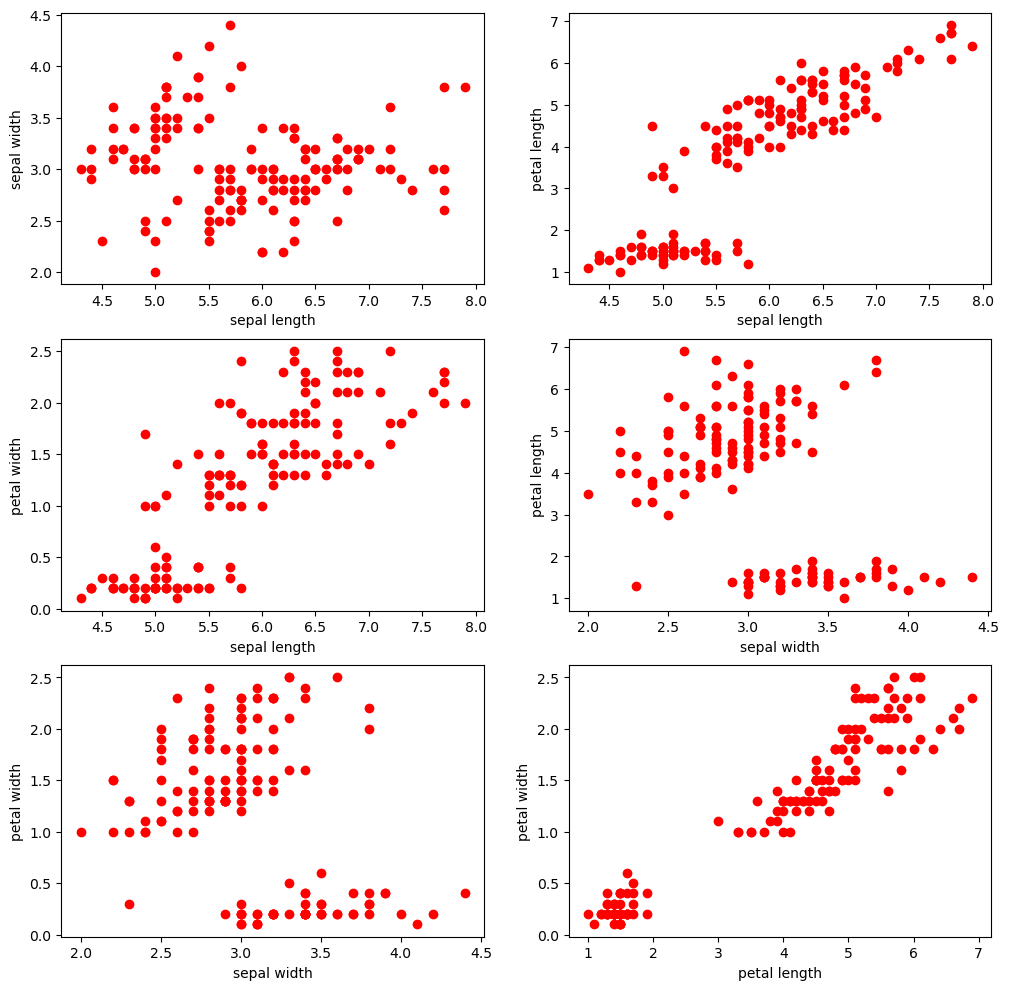

```python
import matplotlib.pyplot as plt

fig, axes = plt.subplots(3, 2, figsize=(12,12))
index = 0
for i in range(3):
    for j in range(i+1,4):
        ax1 = int(index/2)
        ax2 = index % 2
        axes[ax1][ax2].scatter(data[data.columns[i]], data[data.columns[j]], color='red')
        axes[ax1][ax2].set_xlabel(data.columns[i])
        axes[ax1][ax2].set_ylabel(data.columns[j])
        index = index + 1
```

**4.** Parallel coordinates can be used to display all the data points simultaneously. Parallel coordinates have one coordinate axis for each attribute, but the different axes are parallel to one other instead of perpendicular, as is traditional. Furthermore, an object is represented as a line instead of as a point. In the example below, the distribution of values for each class can be identified in a separate color.

**Code:**

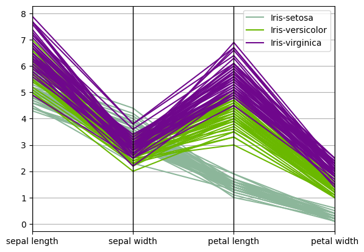

```python
from pandas.plotting import parallel_coordinates
%matplotlib inline

parallel_coordinates(data, 'class')
```

**QUESTION F:** A parallel coordinates plot is an attempt to visualize a multi-dimentional data set. What problem can you identify with the such a visualization?

**YOUR ANSWER:** I suppose it's difficult if not impossible to identify individual cases or observations. Swapping the positions of sepal width and petal length might also make for a cleaner graph.

**QUESTION G:** What critique do you have with the choice of colors reprensenting the different iris species?

**YOUR ANSWER:** The colors for Iris-setosa and Iris-versicolor might be a little to similar to each other.

## 3.3. Summary

This tutorial presents several examples for data exploration and visualization using the Pandas and matplotlib library packages available in Python.

**References:**

1. Documentation on Pandas. https://pandas.pydata.org/
2. Documentation on matplotlib. https://matplotlib.org/
3. Lichman, M. (2013). UCI Machine Learning Repository [http://archive.ics.uci.edu/ml]. Irvine, CA: University of California, School of Information and Computer Science.